# Análise Exploratória dos municípios que adotaram política de isenção de tarifa no transporte público

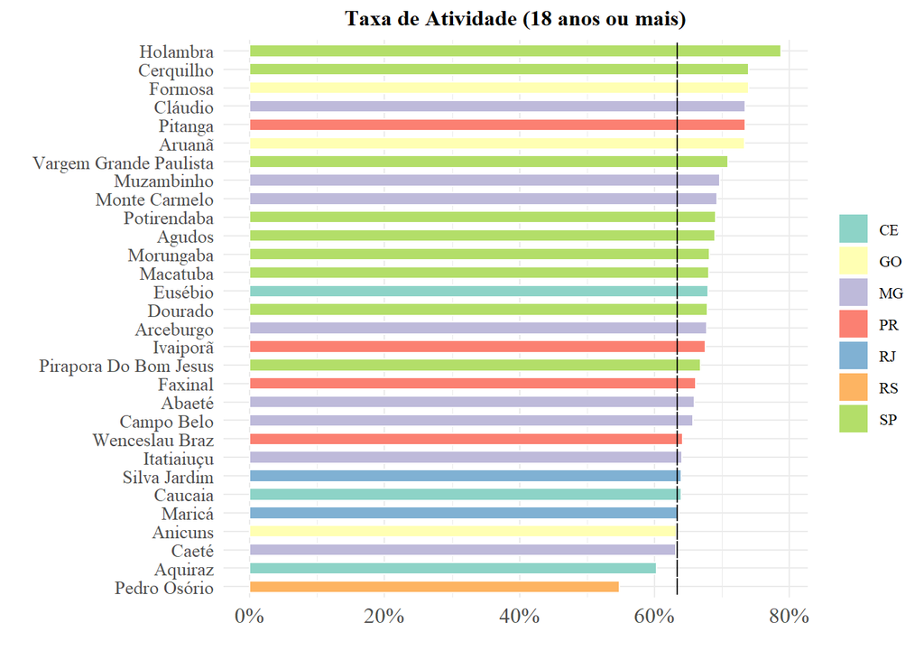

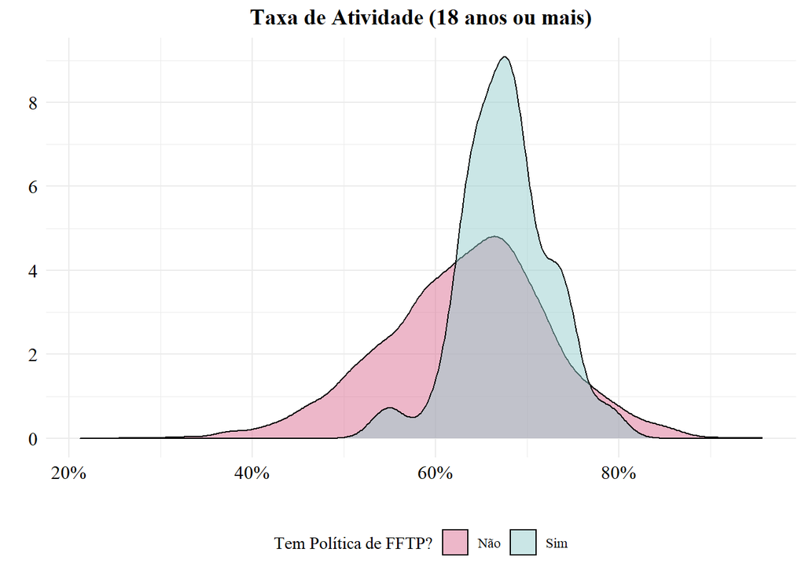

**12. Renda Per Capta Média**

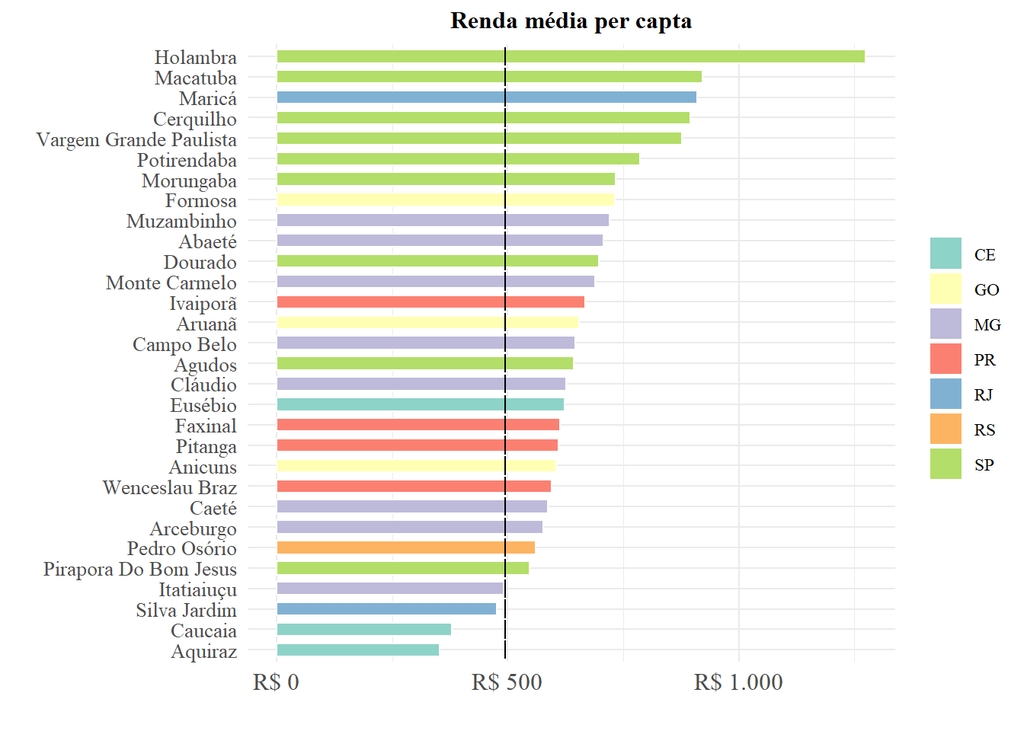

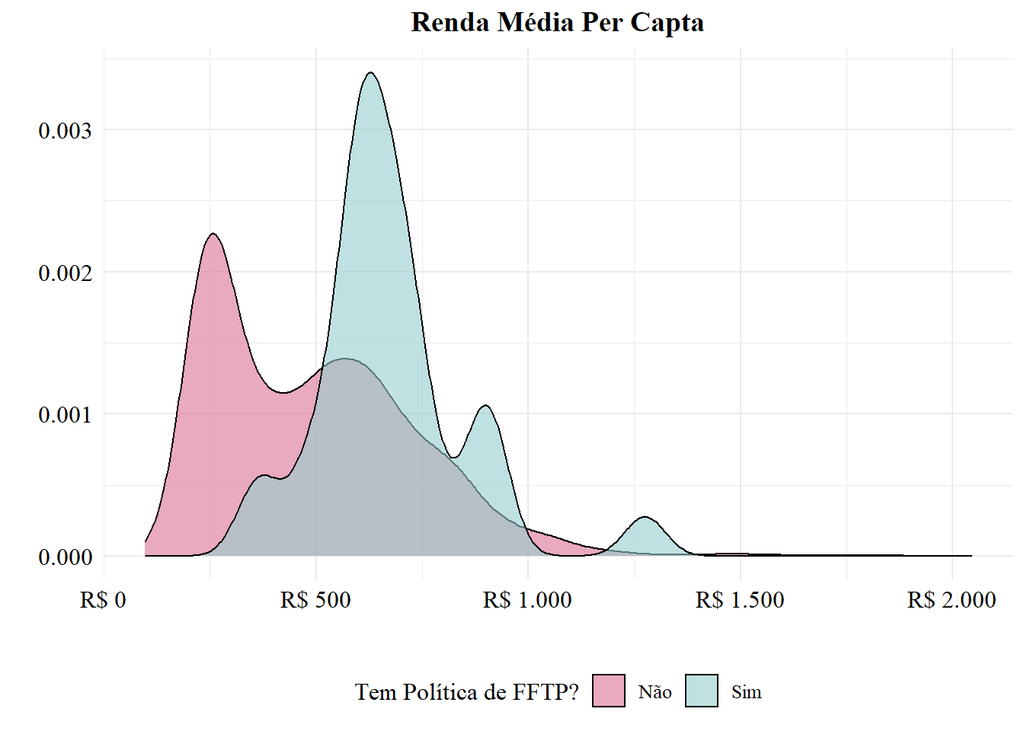

**13. Índice de Vulnerabilidade Social (IVS)**

| IVS | Alta | Baixa | Média | Muito Baixa | Alta | Baixa | Média | Muito Baixa |
| --- | --- | --- | --- | --- | --- | --- | --- | --- |
| Capital Humano | 23% | 40% | 30% | 7% | 51% | 20% | 26% | 2% |
| Geral | 7% | 53% | 23% | 17% | 36% | 30% | 23% | 11% |
| Infraestrutura Urbana | 13% | 23% | 10% | 53% | 16% | 20% | 14% | 51% |
| Renda e Trabalho | 7% | 40% | 33% | 20% | 48% | 24% | 22% | 6% |

Segundo o Atlas da Vulnerabilidade Social nos Municípios brasileiros, publicado IPEA em 2015, o Indice de Vulnerabilidade Social é um índice construídos com dados do censo brasileiro, que varia entre 0 e 1, sendo que quanto mais próximo a 1, maior é a vulnerabilidade social de um município. O Atlas também indica a seguinte classificação dos valores atribuídos pelo índice a cada município:

- Entre 0 e 0,200 - muita baixa vulnerabilidade social,
- Entre 0,201 e 0,300 - baixa vulnerabilidade social,
- Entre 0,301 e 0,400 - média vulnerabilidade social,
- Entre 0,401 e 0,500 são considerados de alta vulnerabilidade social

Levando essa classificação em conta, a média dos municípios que adotaram a FFTP ficou em 0.27 o que indica baixa vulneravilidade social. A media nos municípios que não adotaram a política ficou em 0.352, o que indica uma situação de média vulnerabilidade social. O primeiro grupo também apresenta um valor máximo de 0.441 referente a cidade de Caucaia no Ceará, representando alta vulnerabilidade social, e no outro extreno o valor de 0.117 na cidade de Holambra em São Paulo, correspondendo a muita baixa vulnerabilidade social. No gráfico abaixo podemos observar que os municípios com FFTP estão mais à esquerda do gráfico em relação a todos os outros municípios brasileiros o que indica que eles estão, em geral, em situção de menor vulnerabilidade social, sendo o indicador de infraestrutura urbana o único com bem pouca diferença entre os dois grupos. Comparando as médias desse último indicador temos que os municípios com FFTP apresentam o valor de 0.206, enquanto nos municípios que não adotaram é 0.233, há bem pouca diferença, no entanto sugere que o primeiro grupo de cidades tem um infraestrutura urbana melhor que o segundo grupo.

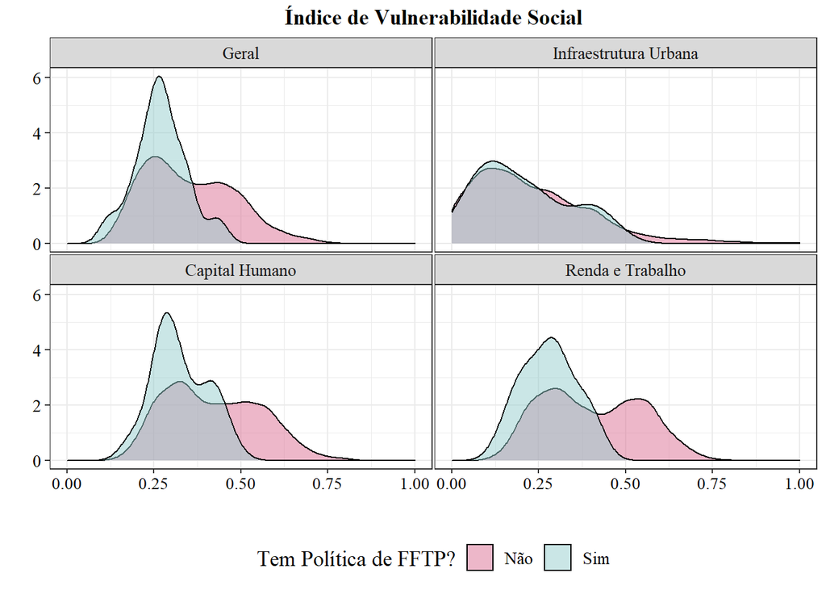

**14. Índice de Desenvolvimento Humano (IDHM)**

| IDHM | Alta | Média | Baixa | Muito Alto | Alta | Baixa | Média | Muito Alto | Muito Baixa |
| --- | --- | --- | --- | --- | --- | --- | --- | --- | --- |
| Geral | 67% | 33% | 0% | 0% | 34% | 25% | 40% | 1% | 1% |
| Educação | 3% | 63% | 33% | 0% | 6% | 36% | 29% | 0% | 29% |
| Longevidade | 17% | 0% | 0% | 83% | 42% | 0% | 1% | 57% | 0% |
| Renda | 57% | 40% | 0% | 3% | 28% | 32% | 36% | 1% | 2% |

“O Índice de Desenvolvimento Humano Municipal (IDHM) é uma medida composta de indicadores de três dimensões do desenvolvimento humano: longevidade, educação e renda. O índice varia de 0 a 1. Quanto mais próximo de 1, maior o desenvolvimento humano.”(PNUD,2021). Segue a classificação:

- Entre 0 e 0,499 - muito baixo
- Entre 0,500 e 0,599 - baixo
- Entre 0,600 e 0,699 - médio
- Entre 0,700 e 0,799 - alto
- Entre 0,800 e 1 - muito alto

O IDHM médio dos municípios estudados é de 0.72, o que indica idhm “alto”, enquanto a média nos municípios brasileiros que não adotaram a política é 0.66, o que indica idhm “médio”. Olhando para a distribuição dos valores para os dois grupos de municípios podemos perceber que os municípios que adotaram a política possuem valores de IDHM ligeiramente maiores.

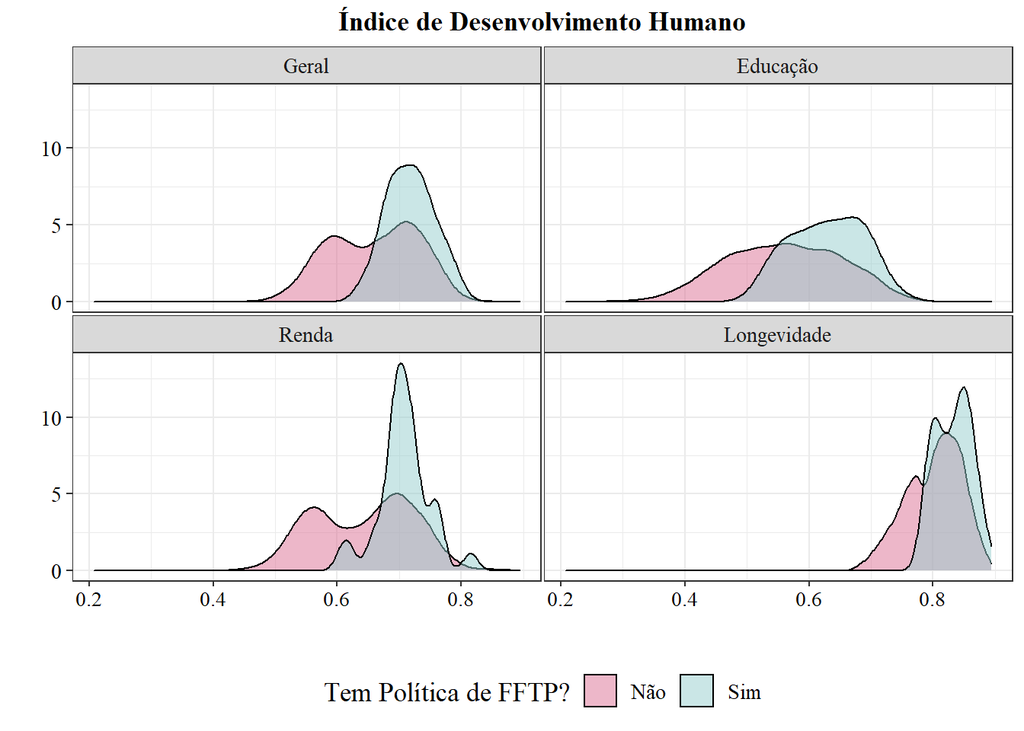

Por fim, a média do IDHM longevidade dos municípios estudados é de 0.83 enquanto a média nos municípios brasileiros que não adotaram a política é 0.8.Aqui há apenas uma pequena diferença entre os dois grupos, que estão no mesmo grupo de idhm “muito alto”.

A respeito dos indicadores de IDHM: renda, educação e longevidade, podemos dizer que, em termos de renda e educação, os municípios que adotaram o FFTP tem uma diferença de 7 pontos a mais na média de valores do indicador em relação aos municípios sem essa política. Em relação a longevidade, as médias apresentam valores praticamente semelhantes.

**16. Movimentos Sociais e Tarifa Zero**

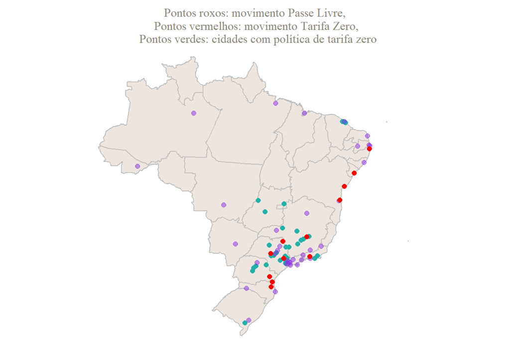